# Flight Delays Prediction / Analytics

#### Almost perfect normal distribution

```r
# Correlation
a<-cor(traintripsdep$DepDelay,
       traintripsdep$pred.DepDelay )
b<-cor(validtrips$DepDelay,
       validtrips$predict.DepDelay )
a
```

```
## [1] 1
```

```r
b
```

```
## [1] 1
```

```r
a*a
```

```
## [1] 1
```

```r
b*b
```

```
## [1] 0.9999999
```

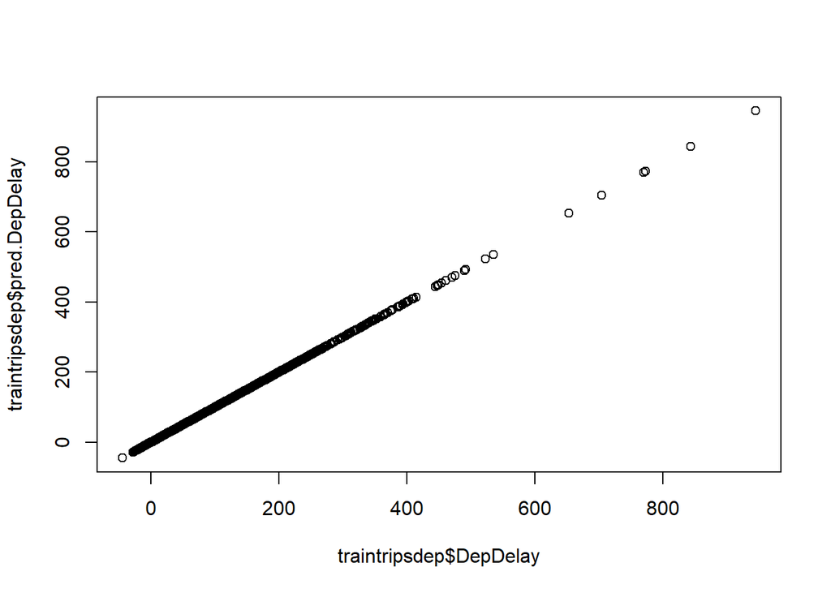

```r
plot(traintripsdep$DepDelay,
     traintripsdep$pred.DepDelay )
```

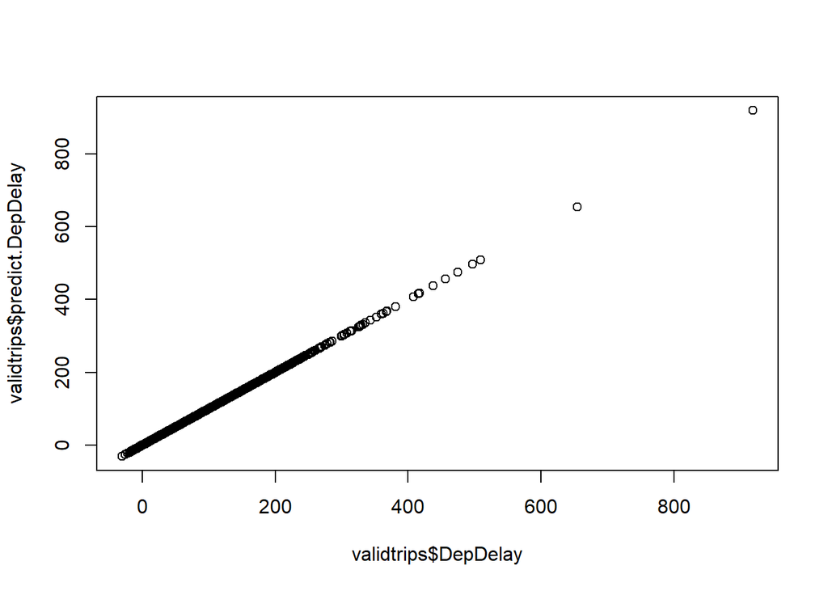

```r
plot(validtrips$DepDelay,
     validtrips$predict.DepDelay )
```

#### If we look at the Actual vs Predicted it almost follows stright line over diaognal

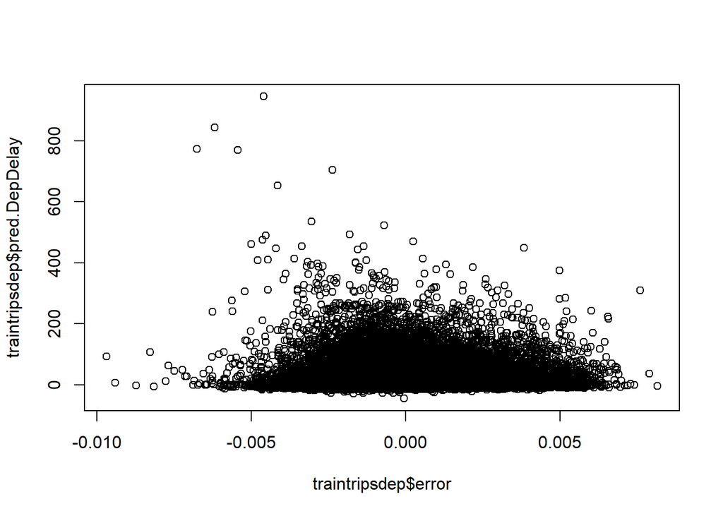

```r
plot(traintripsdep$error,
     traintripsdep$pred.DepDelay )
```

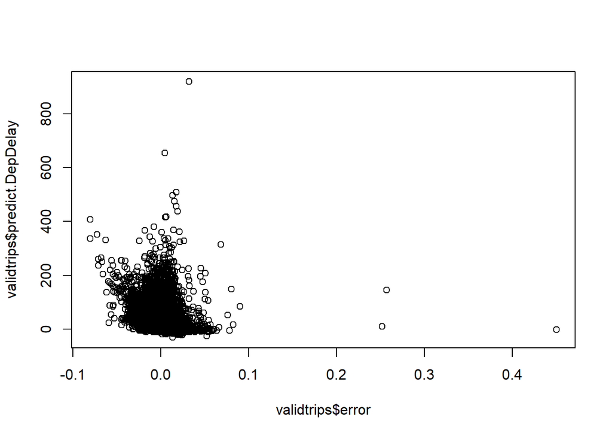

```r
plot(validtrips$error,
     validtrips$predict.DepDelay )
```

#### Model performance is good and accuracy is good as well.

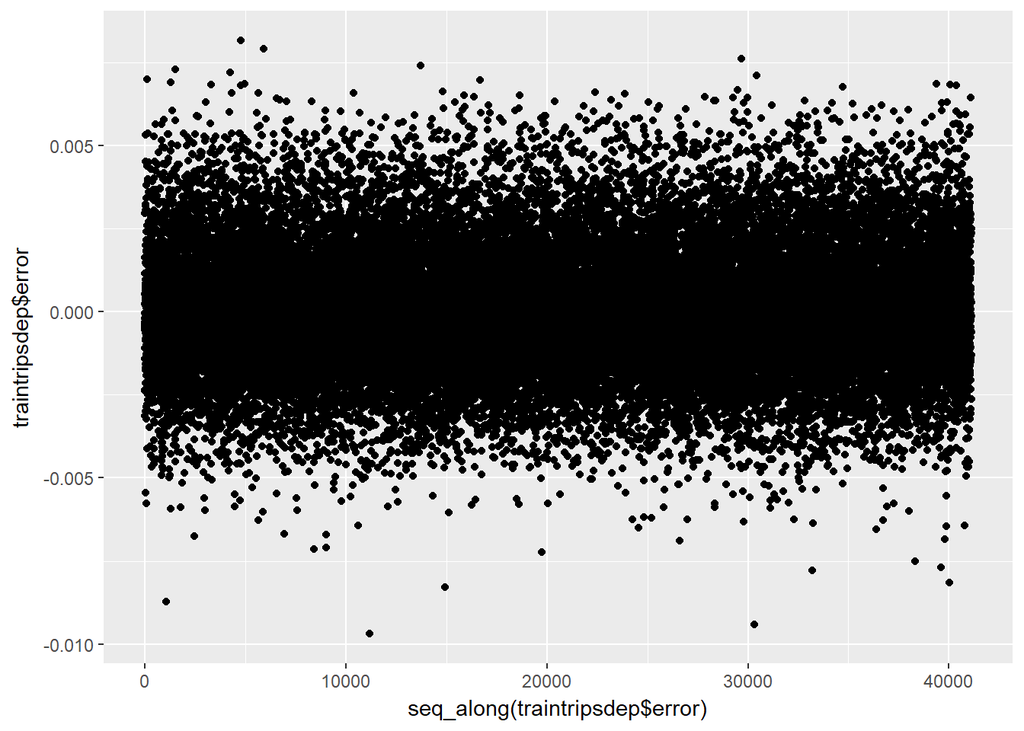

```r
qplot(y=traintripsdep$error)
```

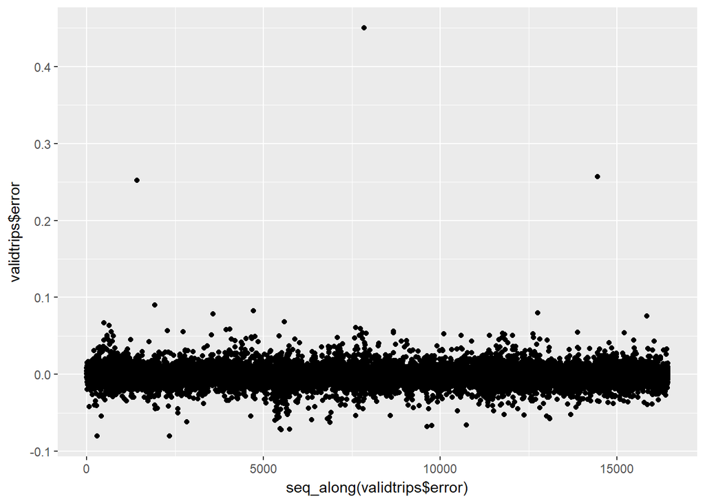

```r
qplot(y=validtrips$error)
```

Though we have tested each and every independent variable and max combinations before choosing final model. We have used alternate methods to choose variables. One of such methods is AIC. This takes combinations of variables and computes statistics. We have run STEP AIC and even with the first model seems to be best. Not showing STEPAIC here to save some real estate. In the actual code file we have it.

#### Even if we get better model by tweeking the variables. It may not do well on completely new data.

#### Let’s verify both the models on test data set and conclude at the end.

### Now it’s time to predict ArrDelay as well. We can use DespDelay as well for predicting Arrival Delay.

Here, we can assume that DepDelay information is available and predict!. There is strong co-relation between two. This will be a very good predictor. Also, later we will make DepDelay not available and predict.

```r
traintripsArr <- traintrips
#traintripsArr <- traintrips[, !grepl("DepDelay" , names(traintrips))]  # Removing Arrvilal related variables.

lm.arr.fit1 <- stats::lm(ArrDelay ~ . , data=traintripsArr)

summary(lm.arr.fit1)
```

```
##
## Call:
## stats::lm(formula = ArrDelay ~ ., data = traintripsArr)
##
## Residuals:
##     Min      1Q  Median      3Q     Max
## -48.339  -3.645   0.614   4.331 129.869
##
## Coefficients: (9 not defined because of singularities)
##                             Estimate Std. Error t value Pr(>|t|)
## (Intercept)                11.706149   1.313782   8.910  < 2e-16 ***
## `as.factor(Month)2`         0.428346   0.186457   2.297 0.021607 *
## `as.factor(Month)3`        -0.347787   0.180585  -1.926 0.054125 .
## `as.factor(Month)4`        -0.018060   0.181340  -0.100 0.920669
## `as.factor(Month)5`        -0.385228   0.181679  -2.120 0.033981 *
## `as.factor(Month)6`         0.365904   0.180385   2.028 0.042519 *
## `as.factor(Month)7`        -0.173978   0.179940  -0.967 0.333615
## `as.factor(Month)8`        -0.351935   0.180335  -1.952 0.050997 .
## `as.factor(Month)9`        -1.342589   0.186666  -7.192 6.47e-13 ***
## `as.factor(Month)10`       -0.760527   0.183717  -4.140 3.49e-05 ***
## `as.factor(Month)11`       -1.343603   0.184844  -7.269 3.69e-13 ***
## `as.factor(Month)12`        0.383650   0.180805   2.122 0.033852 *
## `as.factor(DayOfWeek)2`    -0.273609   0.133746  -2.046 0.040789 *
## `as.factor(DayOfWeek)3`    -0.200706   0.133523  -1.503 0.132805
## `as.factor(DayOfWeek)4`     0.445079   0.132899   3.349 0.000812 ***
## `as.factor(DayOfWeek)5`     0.390612   0.131510   2.970 0.002978 **
## `as.factor(DayOfWeek)6`    -0.765021   0.140148  -5.459 4.82e-08 ***
## `as.factor(DayOfWeek)7`    -0.150642   0.134221  -1.122 0.261723
## UniqueCarrierAQ            -1.728162   0.676635  -2.554 0.010651 *
## UniqueCarrierAS            -1.643909   0.368157  -4.465 8.02e-06 ***
## UniqueCarrierB6            -2.061308   0.293811  -7.016 2.32e-12 ***
## UniqueCarrierCO            -1.450814   0.248901  -5.829 5.62e-09 ***
## UniqueCarrierDL            -0.503381   0.255760  -1.968 0.049054 *
## UniqueCarrierEV            -0.222776   0.310641  -0.717 0.473287
## UniqueCarrierF9             1.105819   0.365519   3.025 0.002485 **
## UniqueCarrierFL             1.181621   0.284070   4.160 3.19e-05 ***
## UniqueCarrierHA            -0.935838   0.627147  -1.492 0.135650
## UniqueCarrierMQ             0.322449   0.220309   1.464 0.143305
## UniqueCarrierNW             1.465462   0.298076   4.916 8.85e-07 ***
## UniqueCarrierOH             0.029488   0.305169   0.097 0.923023
```

[output cut: 163 more lines]

```
## `as.factor(Originstate)WI` -2.492319   0.792310  -3.146 0.001658 **
## `as.factor(Originstate)WV` -3.047729   1.707219  -1.785 0.074236 .
## `as.factor(Originstate)WY` -2.028296   1.263581  -1.605 0.108458
## TaxiOut                     4.006934   0.055901  71.679  < 2e-16 ***
## CarrierDelay               18.483184   0.097596 189.385  < 2e-16 ***
## WeatherDelay                8.588238   0.054625 157.220  < 2e-16 ***
## NASDelay                   16.989697   0.074749 227.291  < 2e-16 ***
## LateAircraftDelay          19.728674   0.103747 190.162  < 2e-16 ***
## DepDelay                    0.264562   0.003585  73.797  < 2e-16 ***
## ---
## Signif. codes:  0 '***' 0.001 '**' 0.01 '*' 0.05 '.' 0.1 ' ' 1
##
## Residual standard error: 7.318 on 40918 degrees of freedom
## Multiple R-squared:  0.9732, Adjusted R-squared:  0.9731
## F-statistic:  7746 on 192 and 40918 DF,  p-value: < 2.2e-16
```

#### R-Squared: 97 and Residual error: 7

```
## [1] 7.487147
```

```
## [1] 0.6949463
```

```
## [1] 5.486808
```

### Plots For Arrival Delay

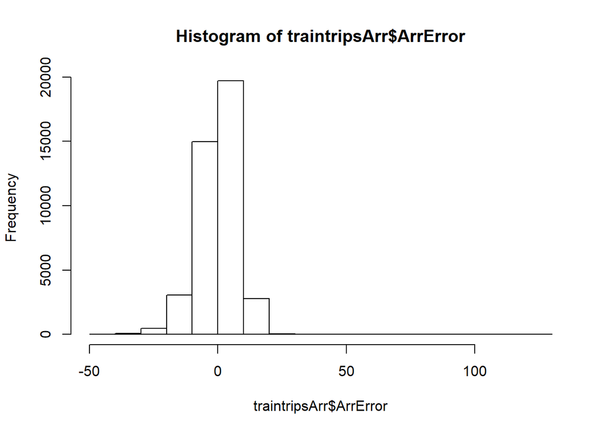

```r
# Check residual plots
hist(traintripsArr$ArrError)
```

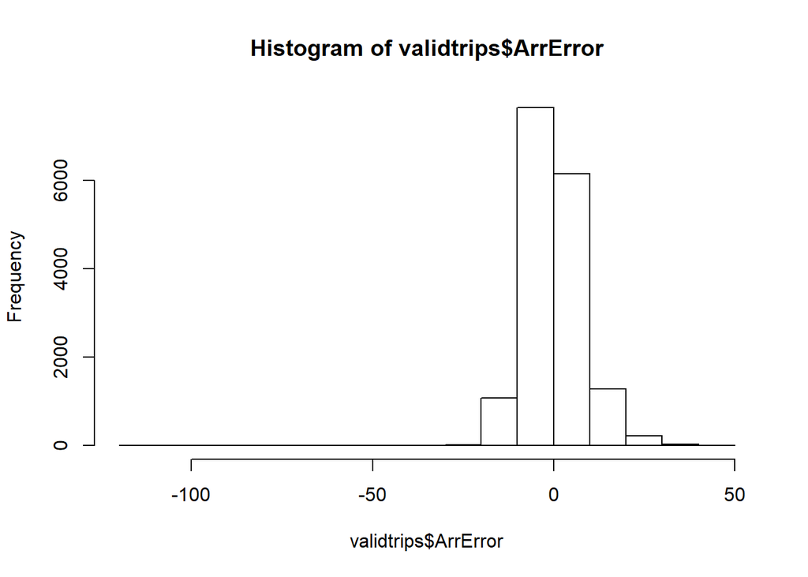

```r
hist(validtrips$ArrError)
```

In both cases the histogram is centered at zero. Espicially with Test data. This is a good test. Follows nornal distribution which is a good measure of model performance.

#### Correlation

```r
a<-cor(traintripsArr$ArrDelay,
       traintripsArr$pred.ArrDelay )
b<-cor(validtrips$ArrDelay,
       validtrips$predict.ArrDelay )
a
```

```
## [1] 0.9865212
```

```r
b
```

```
## [1] 0.9865064
```

```r
a*a
```

```
## [1] 0.9732242
```

```r
b*b
```

```
## [1] 0.9731949
```

co-relation between actul and predicted is very high satisfying the accuracy of the model.

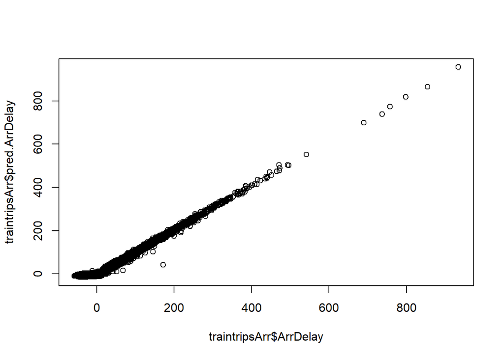

```r
plot(traintripsArr$ArrDelay,
     traintripsArr$pred.ArrDelay )
```

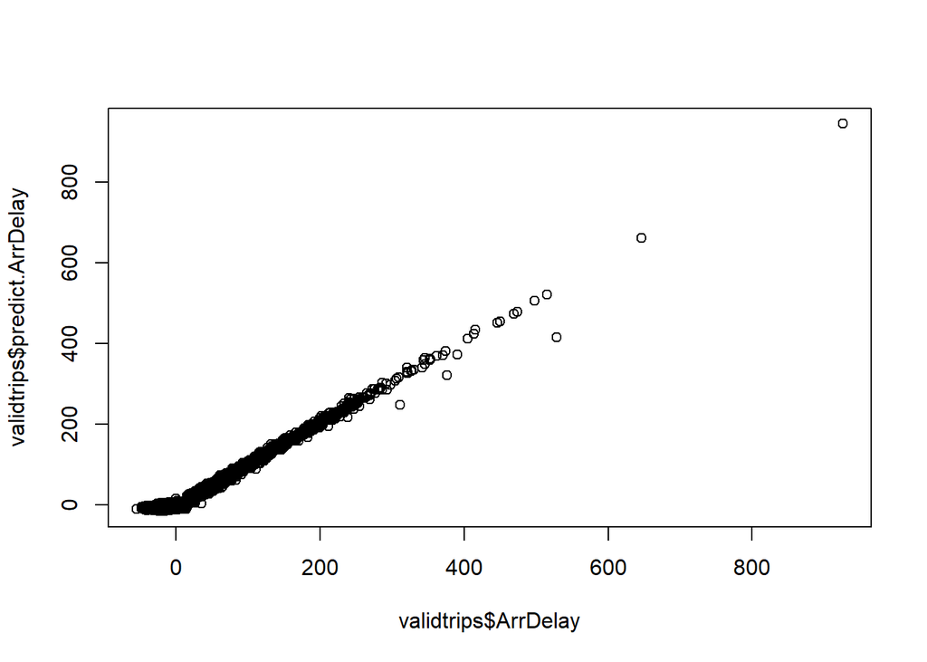

```r
plot(validtrips$ArrDelay,
     validtrips$predict.ArrDelay )
```

If we look at the Actual vs Predicted it almost follows stright line over diaognal.

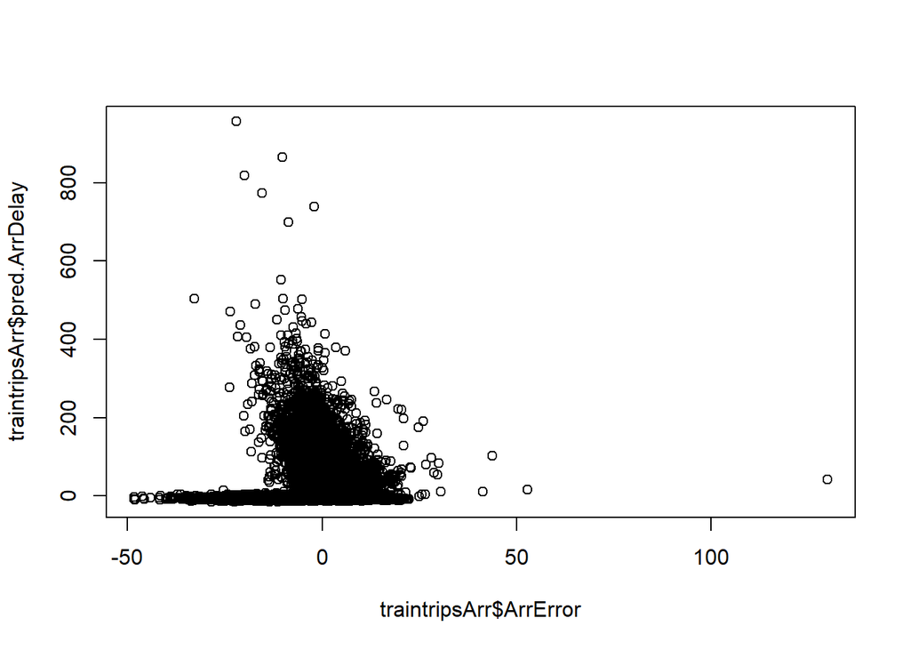

```r
plot(traintripsArr$ArrError,
     traintripsArr$pred.ArrDelay )
```

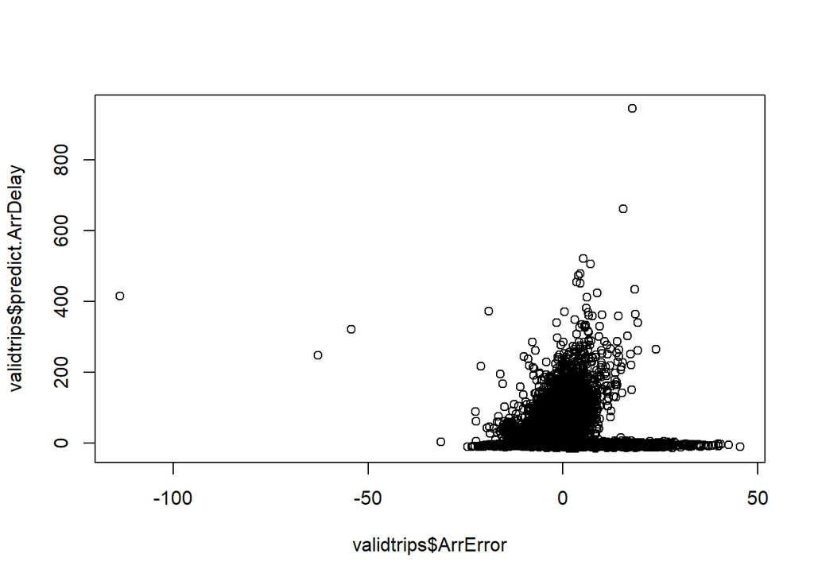

```r
plot(validtrips$ArrError,
     validtrips$predict.ArrDelay )
```

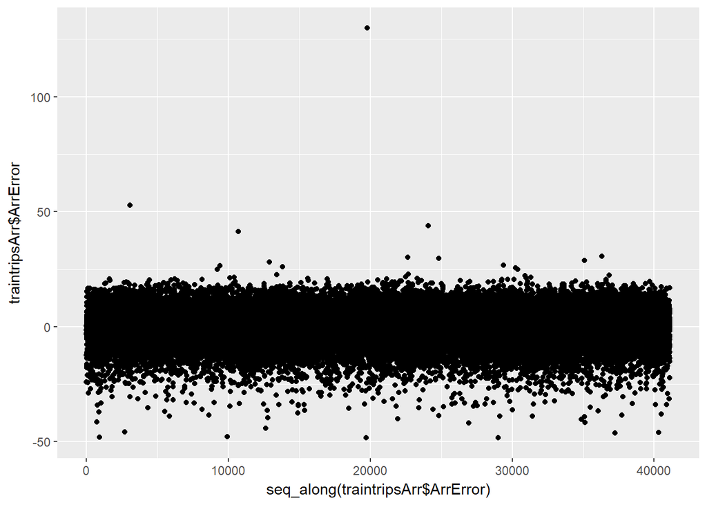

```r
qplot(y=traintripsArr$ArrError)
```

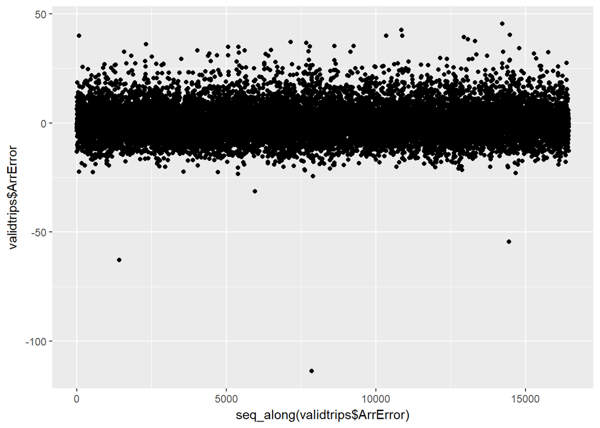

```r
qplot(y=validtrips$ArrError)
```

Follows normal distributuon. #### Model performance is good and accuracy is good as well.

#### We can try removing DepDelay (independent variable) and try and predict the ArrDelay.

Not showing all the plotsto sae some realestate. But in actual code file, we have it.

[output not shown]

[output cut: 86 more lines]

```
## [1] 203
```

```
##
## Call:
## stats::lm(formula = ArrDelay ~ ., data = traintripsArr)
##
## Residuals:
##     Min      1Q  Median      3Q     Max
## -50.780  -3.559   1.015   3.812 174.400
##
## Coefficients: (9 not defined because of singularities)
##                             Estimate Std. Error t value Pr(>|t|)
## (Intercept)                16.205795   1.396957  11.601  < 2e-16 ***
## `as.factor(Month)2`         0.422479   0.198476   2.129 0.033292 *
## `as.factor(Month)3`        -0.247787   0.192220  -1.289 0.197377
## `as.factor(Month)4`        -0.092255   0.193026  -0.478 0.632694
## `as.factor(Month)5`        -0.460409   0.193387  -2.381 0.017281 *
## `as.factor(Month)6`         0.505443   0.192001   2.633 0.008479 **
## `as.factor(Month)7`         0.077348   0.191504   0.404 0.686290
## `as.factor(Month)8`        -0.100357   0.191924  -0.523 0.601047
## `as.factor(Month)9`        -1.487052   0.198687  -7.484 7.33e-14 ***
## `as.factor(Month)10`       -0.767986   0.195559  -3.927 8.61e-05 ***
## `as.factor(Month)11`       -1.292840   0.196757  -6.571 5.07e-11 ***
## `as.factor(Month)12`        0.507618   0.192451   2.638 0.008352 **
## `as.factor(DayOfWeek)2`    -0.433488   0.142349  -3.045 0.002326 **
## `as.factor(DayOfWeek)3`    -0.297485   0.142122  -2.093 0.036341 *
## `as.factor(DayOfWeek)4`     0.367164   0.141461   2.596 0.009448 **
## `as.factor(DayOfWeek)5`     0.495583   0.139979   3.540 0.000400 ***
## `as.factor(DayOfWeek)6`    -0.837162   0.149178  -5.612 2.01e-08 ***
## `as.factor(DayOfWeek)7`    -0.185865   0.142871  -1.301 0.193291
## UniqueCarrierAQ            -2.049608   0.720234  -2.846 0.004433 **
## UniqueCarrierAS            -2.147687   0.391820  -5.481 4.25e-08 ***
## UniqueCarrierB6            -1.895081   0.312740  -6.060 1.38e-09 ***
## UniqueCarrierCO            -0.966091   0.264851  -3.648 0.000265 ***
## UniqueCarrierDL            -0.417301   0.272242  -1.533 0.125325
## UniqueCarrierEV             0.139429   0.330623   0.422 0.673235
## UniqueCarrierF9             0.876868   0.389065   2.254 0.024215 *
## UniqueCarrierFL             0.193793   0.302045   0.642 0.521135
## UniqueCarrierHA            -1.735020   0.667471  -2.599 0.009342 **
## UniqueCarrierMQ            -0.042338   0.234450  -0.181 0.856694
## UniqueCarrierNW             1.131931   0.317252   3.568 0.000360 ***
## UniqueCarrierOH             0.251056   0.324824   0.773 0.439587
```

[output cut: 162 more lines]

```
## `as.factor(Originstate)WA` -0.557790   0.722972  -0.772 0.440401
## `as.factor(Originstate)WI` -1.970382   0.843345  -2.336 0.019476 *
## `as.factor(Originstate)WV` -3.048133   1.817260  -1.677 0.093487 .
## `as.factor(Originstate)WY` -2.283867   1.345022  -1.698 0.089513 .
## TaxiOut                     1.701929   0.049350  34.487  < 2e-16 ***
## CarrierDelay               25.126633   0.040122 626.255  < 2e-16 ***
## WeatherDelay               11.601710   0.038622 300.392  < 2e-16 ***
## NASDelay                   21.497318   0.045863 468.725  < 2e-16 ***
## LateAircraftDelay          26.844295   0.040760 658.589  < 2e-16 ***
## ---
## Signif. codes:  0 '***' 0.001 '**' 0.01 '*' 0.05 '.' 0.1 ' ' 1
##
## Residual standard error: 7.79 on 40919 degrees of freedom
## Multiple R-squared:  0.9697, Adjusted R-squared:  0.9695
## F-statistic:  6847 on 191 and 40919 DF,  p-value: < 2.2e-16
```

It may predict well on Validation data set.

#### Even here model performance is good and accuracy is good as well.

#### We can use eaither of the models. If it is for predicting much earlier say week before the flight, then we don’t have DepDelay info so we can use second on. But if you are using for realtime flight delay prediction than we can use first one.

#### Finally, we need to apply this model to test data set to see the results.

### And once this is ready, we need to use the final model in function which accepts these input variables as parameters and predicts the delay.